# Adaptive Squeezed Rejection Sampling

Amy Chen

October 23, 2018

### Overview

Adaptive squeezed rejection sampling is a method of drawing points from a target distribution, and goes a step further than rejection sampling by utilizing an automatic envelope generation strategy for squeezed rejection sampling.  
Suppose we are interested in drawing points from $f(x)$, a concave function. Let $g$ denote another density from which we know how to sample and for which we can easily calculate $g(x)$. Let $e$ denote an envelope such that $e(x) = \frac{g(x)}{\alpha}\geq f(x) \forall x$ for which $f(x) > 0$ for a given constant $\alpha \leq 1$. It is simpler to generate this envelope function in the log space. Take $n$ points on $log(f(x))$ and connect their tangent lines to determine $log(e(x))$. This ensures that when exponentiated, the envelope function encompasses $f(x)$.  
We will also define a squeeze function $s(x)$ such that $s(x) \leq f(x) \forall x$ for which $f(x) > 0$. Using the selected points from generating the envelope function, connect the points to determine $log(s(x))$. This ensures that when exponentiated, the squeeze function is below $f(x)$.  
Then adaptive rejection sampling can be completed in the following steps:

1. Sample $Y$ ~ $g$
2. Sample $U$ ~ $Unif(0,1)$
3. If $U \leq \frac{s(Y)}{e(Y)}$, keep $Y$
4. If $U > \frac{s(Y)}{e(Y)}$ and $U \leq \frac{f(Y)}{e(Y)}$, keep $Y$
5. Otherwise, reject $Y$
6. Repeat for desired sample size

### Demonstration

**Suppose we would like to estimate $S= E[x^2]$ where $X$ has density proportional to $q(x) = e^ \frac{-|x|^3}{3}\$**

#### Target Function

Let the target function be $f(x) = e^ \frac{-|x|^3}{3}\$  
Then $log(f(x)) = \frac{-|x|^3}{3}\$

#### Envelope Function

Select points $(-1$, $-\frac{1}{3} )$, $(0$, $0)$, and $(1$, $-\frac{1}{3} )$ from $log(f(x))$
By computing the tangent lines at each point, finding the points of intersection, and merging the functions, we get the log of the envelope function,
$$log(e(x)) =
\begin{cases}
0 & \text{if $-\frac{2}{3} < x < \frac{2}{3}$} \\
\frac{2}{3} - |x| & \text{$otherwise$} \\
\end{cases}$$
Exponentiate to get the envelope function,
$$e(x) =
\begin{cases}
1 & \text{if $-\frac{2}{3} < x < \frac{2}{3}$} \\
e^{\frac{2}{3}} - |x| & \text{$otherwise$} \\
\end{cases}$$

#### Squeezing Function

Let the log of the squeezing function be $log(s(x)) = -\frac{|x|}{3}$ if $-1 < x < 1$  
Exponentiate to get the squeezing function $s(x) = e^{-\frac{|x|}{3}}$ if $-1 < x < 1$

```r
logf <- function(x) {
  -abs(x^3)/3
}
loge <- function(x) {
  ifelse( (x>-2/3)&(x<2/3), 0, 2/3-abs(x) );
}
logs <- function(x) {
  ifelse( (x>-1)&(x<1), -abs(x)/3, NA );
}
```

```r
f <- function(x) {
  exp(logf(x))
}
e <- function(x) {
  exp(loge(x));
}
s <- function(x) {
  exp(logs(x));
}
```

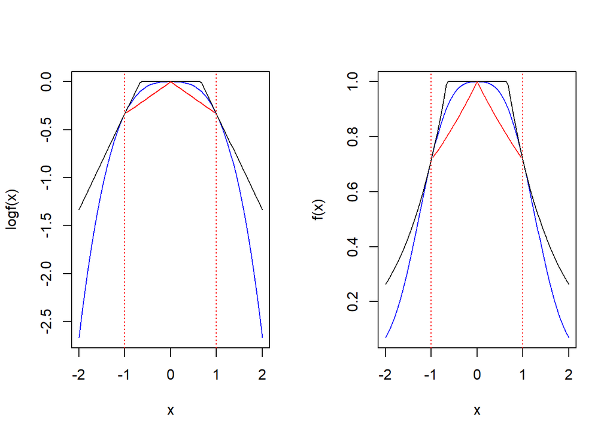

```r
par(mfrow=c(1,2))
curve(logf(x), from = -2, to = 2, col = "blue")
curve(loge(x), add = T)
curve(logs(x), add = T, col = "red")
abline(v = -1, lty = 3,col = "red")
abline(v = 1, lty = 3,col = "red")

curve(f(x), from = -2, to = 2, col = "blue")
curve(e(x), add = T)
curve(s(x), add = T, col = "red")
abline(v = -1, lty = 3,col = "red")
abline(v = 1, lty = 3,col = "red")
```

#### Finding Inverse CDF $G^{-1}$

$\int_{-\infty}^{\infty} e(x) \; dx = \int_{-\infty}^{-\frac{2}{3}} e^{\frac{2}{3} + x } \; dx + \int_{-\frac{2}{3}}^{\frac{2}{3}} e^{0} \; dx + \int_{\frac{2}{3}}^{\infty} e^{\frac{2}{3} - x } \; dx = \frac{10}{3}$
So the normalizing constant is $\frac{3}{10}$
Then the CDF of $g$ is
$$G(x) =
\begin{cases}
\frac{3}{10}e^{\frac{2}{3}+x} & \text{if $x< -\frac{2}{3}$} \\
\frac{3}{10}x + \frac{1}{2} & \text{if $-\frac{2}{3} \leq x \leq \frac{2}{3}$} \\
1-\frac{3}{10}e^{\frac{2}{3}-x} & \text{if $x > \frac{2}{3}$} \\
\end{cases}$$

Take the inverse of $G(x)$,
$$G^{-1}(u) =
\begin{cases}
log(\frac{10}{3}u)-\frac{2}{3} & \text{if $0 < u < \frac{3}{10}$} \\
\frac{10}{3}(u-\frac{1}{2}) & \text{$-\frac{3}{10} \leq u \leq \frac{7}{10}$} \\
\frac{2}{3}-log(\frac{10}{3}(1-u)) & \text{$\frac{7}{10} < u < 1$} \\
\end{cases}$$

```r
Ginv <- function(u) {
  ifelse(u<3/10, log(u*10/3)-2/3, ifelse(u>7/10, 2/3-log((1-u)*10/3),(u-1/2)*10/3));
}
```

#### Adaptive Rejection Sampling

Below is a function for performing rejection sampling with a sample size of $n$ points.

```r
# adaptive rejection sampling function
ars <- function(n) {
  x <- rep(NA, n);
  # number of points accepted
  ct <- 0;
  # number of points sampled
  total <- 0;
  # number of points caught by squeeze
  squeeze <- 0;

  while(ct < n) {
    y <- Ginv(runif(1));
    u <- runif(1);
    # check squeeze range
    if(y > -1 && y < 1) {
      # under squeeze
      if(u < s(y)/e(y)) {
          ct <- ct + 1;
          x[ct] <- y;
          squeeze <- squeeze + 1;
      }
      # above squeeze
      else {
        # under f
        if(u < f(y)/e(y)) {
          ct <- ct + 1;
          x[ct]<-y;
        }
      }
    }
    # outside squeeze but under f
    else if(u < f(y)/e(y)) {
      ct <- ct + 1;
      x[ct] <- y;
    }

    total <- total + 1;
  }

  list(x = x, acratio_sx = squeeze/total, acratio = ct/total);
}
```

Choose a sample size of 100,000. Below are a few points drawn using this method.

```r
samp_size = 100000
set.seed(920)
ars_points <- ars(samp_size)
head(ars_points$x)
```

```
## [1]  0.2950836  1.3434853  1.1435056 -1.3004348 -0.3099414  0.1288534
```

The theoretical evelope ratio is $\frac{\int_{-\infty}^{\infty} f(x)\;dx}{\int_{-\infty}^{\infty} e(x)\;dx}$, the proportion of points in $f$ that are in $e$.

```r
integrate(f, lower = -Inf, upper = Inf)$value / integrate(e, lower = -Inf, upper = Inf)$value
```

```
## [1] 0.7727395
```

For this simulation, the envelope ratio is

```r
ars_points$acratio
```

```
## [1] 0.7754643
```

The theoretical squeeze ratio is $\frac{\int_{-1}^{1} s(x)\;dx}{\int_{-\infty}^{\infty} e(x)\;dx}$, the proportion of points in $s$ that are in $e$.

```r
integrate(s, lower = -1, upper = 1)$value / integrate(e, lower = -Inf, upper = Inf)$value
```

```
## [1] 0.5102436
```

For this simulation, the squeeze ratio is

```r
ars_points$acratio_sx
```

```
## [1] 0.512706
```

#### Calculate $E[x^2]$

Now that we have our points from the sample, square each accepted x, and take the mean to get $E[x^2]$.

```r
mean(ars_points$x^2)
```

```
## [1] 0.7762001
```